# Inference for many proportions

## Introducing \(\chi^2\)

## Ex: Diversity at Reed

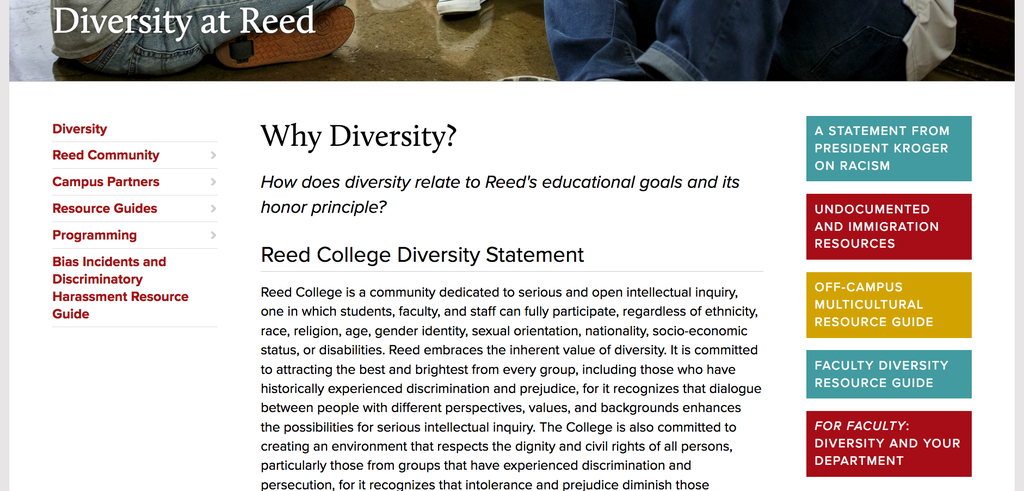

- In terms of ethnic diversity, how does the first year student body compare to the general population of Oregon?

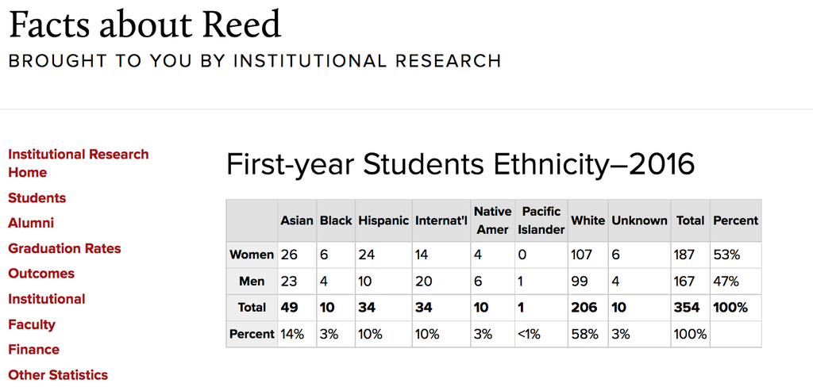

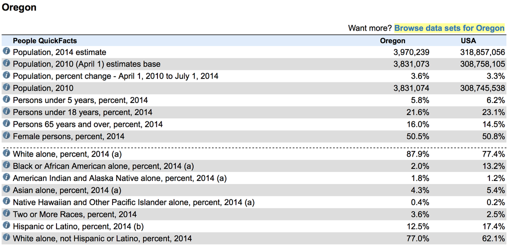

## The data

| Ethnicity | Asian | Black | Hispanic | White | Other | Total |
| --- | --- | --- | --- | --- | --- | --- |
| Reed count | 49 | 10 | 34 | 206 | 55 | 354 |
| Oregon % | .043 | .02 | .125 | .77 | .042 | 1 |

If the students at Reed were drawn from a population with these proportions, how many *counts* would we expect in each group?

\[\textrm{exp. count} = n \times p_i\]

## The data

| Ethnicity | Asian | Black | Hispanic | White | Other | Total |
| --- | --- | --- | --- | --- | --- | --- |
| Obs. count | 49 | 10 | 34 | 206 | 55 | 354 |
| Exp. count | 15.22 | 7.08 | 44.25 | 272.58 | 14.87 | 354 |

- Some sampling variability is expected, but how far from expected is too far?

## Simulating Oregonian Reedies

```r
n <- 354
p <- c(.043, .02, .125, .77, .042)
samp <- factor(sample(c("asian", "black", "hispanic", "white", "other"),
       size = n, replace = TRUE, prob = p),
       levels = c("asian", "black", "hispanic", "white", "other"))
table(samp)
```

```
## samp
##    asian    black hispanic    white    other
##       11       10       40      273       20
```

```r
obs <- c(49, 10, 34, 206, 55)
```

## Simulating Oregonian Reedies

```r
obs <- c(49, 10, 34, 206, 55)
samp <- factor(sample(c("asian", "black", "hispanic", "white", "other"),
       size = n, replace = TRUE, prob = p),
       levels = c("asian", "black", "hispanic", "white", "other"))
table(samp)
```

```
## samp
##    asian    black hispanic    white    other
##       15        6       48      269       16
```

```r
samp <- factor(sample(c("asian", "black", "hispanic", "white", "other"),
       size = n, replace = TRUE, prob = p),
       levels = c("asian", "black", "hispanic", "white", "other"))
table(samp)
```

```
## samp
##    asian    black hispanic    white    other
##       12        8       42      280       12
```

## Simulating Oregonian Reedies

```r
reed_demos %>%
  specify(response = ethnicity) %>%
  hypothesize(null = "point", p = c("asian"    = .043,
                                    "black"    = .02,
                                    "hispanic" = .125,
                                    "white"    = .77,
                                    "other"    = .042)) %>%
  generate(reps = 500, type = "simulate")
```

## Inference on many ps

We *could* do a tests/CIs on \(p_{reed} - p_{oregon}\) for each group, however:

- We have the whole population of Oregon.
- Beware of multiple comparisons!

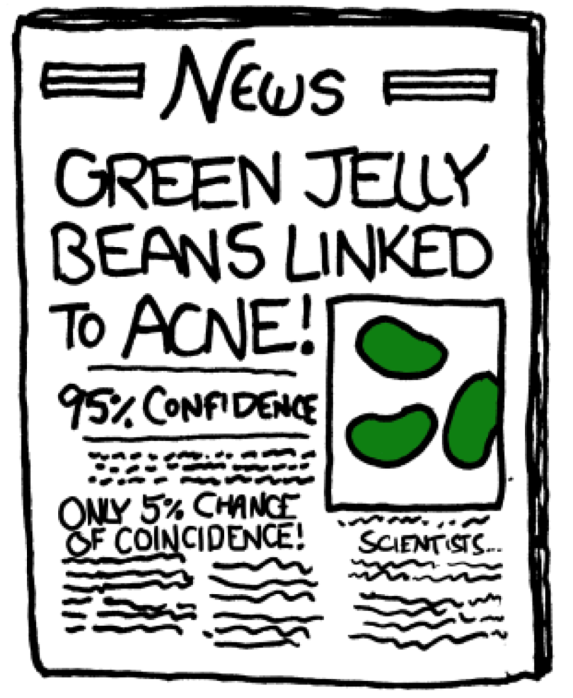


## Creating a statistic

For each of \(k\) categories:

1. Calculate the difference between observed and expected counts.
2. Scale each difference by an estimate of the SE (\(\sqrt(exp)\)).
3. Square the scaled difference to get rid of negatives.

Then add them all up.

\[\chi^2 = \sum_{i = 1}^k \frac{(obs - exp)^2}{exp}\]

| Ethnicity | Asian | Black | Hispanic | White | Other | Total |
| --- | --- | --- | --- | --- | --- | --- |
| Obs. count | 49 | 10 | 34 | 206 | 55 | 354 |
| Exp. count | 15.22 | 7.08 | 44.25 | 272.58 | 14.87 | 354 |

## Simulating \(\chi^2\) under \(H_0\)

```r
null_dist <- reed_demos %>%
  specify(response = ethnicity) %>%
  hypothesize(null = "point", p = c("asian"    = .043,
                                    "black"    = .02,
                                    "hispanic" = .125,
                                    "white"    = .77,
                                    "other"    = .042)) %>%
  generate(reps = 500, type = "simulate") %>%
  calculate(stat = "Chisq")
```

## The null distribution

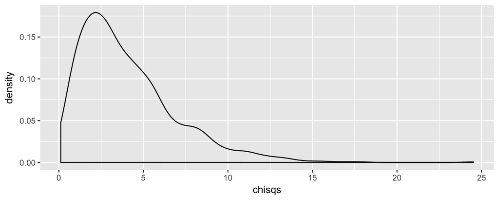

About zero.

## An alternate path to the null

If…

1. Indepedent observations
2. Each cell count has a count \(\ge\) 5
3. \(k \ge 3\)

then our statistic can be well-approximated by the \(\chi^2\) distribution with \(k - 1\) degrees of freedom.

## The null distribution

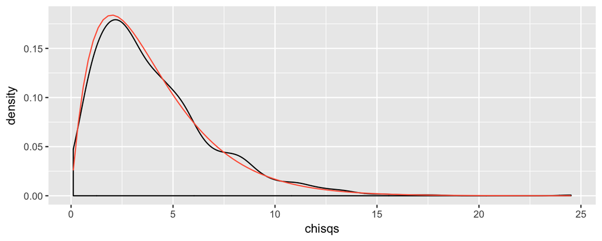

```r
1 - pchisq(206.68, df = 4)
```

```
## [1] 0
```